# time_analysis

### Libraries required for this analysis

```r
knitr::opts_chunk$set(fig.align="center")
library(rstanarm)
library(tidyverse)
library(tidybayes)
library(modelr)
library(ggplot2)
library(magrittr)
library(emmeans)
library(bayesplot)
library(brms)
library(gganimate)

theme_set(theme_light())

source('helper_functions.R')
```

In our experiment, we used a visualization recommendation algorithm (composed of one search algorithm and one oracle algorithm) to generate visualizations for the user on one of two datasets. We then measured the user’s time to complete each of four tasks: 1. Find Extremum 2. Retrieve Value 3. Prediction 4. Exploration

Given a search algorithm (bfs or dfs), an oracle (compassql or dziban), and a dataset (birdstrikes or movies), we would like to predict the time it takes the average user to complete each task. In addition, we would like to know if the choice of search algorithm and oracle has any meaningful impact on a user’s completion time for each of these four tasks,

### Read in and clean data

```r
time_data = read.csv('split_by_participant_groups/completion_time.csv')

time_data <- time_data %>%
  mutate(
    dataset = as.factor(dataset),
    oracle = as.factor(oracle),
    search = as.factor(search),
    task = as.factor(task)
  )
time_data$condition <- paste(time_data$oracle, time_data$search)


task_list = c("1. Find Extremum",
              "2. Retrieve Value",
              "3. Prediction",
              "4. Exploration")

seed = 12
```

## Building a Model for Time Analysis

```r
model <- brm(
    formula = bf(
    completion_time ~ oracle * search + dataset + task + (1 | participant_id)
  ),
    prior = prior(normal(360.48, 224.40), class = "Intercept"),
    chains = 2,
    cores = 2,
    iter = 2500,
    warmup = 1000,
    data = time_data,
    file = "models/time",
    family = lognormal(),
  )
```

### Diagnostics + Model Evaluation

In the summary table, we want to see Rhat values close to 1.0 and Bulk_ESS in the thousands.

```r
summary(model)
```

```
##  Family: lognormal
##   Links: mu = identity; sigma = identity
## Formula: completion_time ~ oracle * search + dataset + task + (1 | participant_id)
##    Data: time_data (Number of observations: 264)
## Samples: 2 chains, each with iter = 2500; warmup = 1000; thin = 1;
##          total post-warmup samples = 3000
##
## Group-Level Effects:
## ~participant_id (Number of levels: 66)
##               Estimate Est.Error l-95% CI u-95% CI Rhat Bulk_ESS Tail_ESS
## sd(Intercept)     0.18      0.04     0.09     0.26 1.00      658      550
##
## Population-Level Effects:
##                        Estimate Est.Error l-95% CI u-95% CI Rhat Bulk_ESS
## Intercept                  5.33      0.09     5.15     5.51 1.00     2516
## oracledziban               0.07      0.10    -0.12     0.26 1.00     1902
## searchdfs                  0.10      0.10    -0.10     0.29 1.00     1912
## datasetmovies             -0.10      0.07    -0.24     0.04 1.00     2641
## task2.RetrieveValue        0.05      0.07    -0.09     0.18 1.00     4122
## task3.Prediction           1.11      0.07     0.98     1.26 1.00     3954
## task4.Exploration          1.21      0.07     1.07     1.35 1.00     3845
## oracledziban:searchdfs    -0.15      0.14    -0.42     0.12 1.00     1746
##                        Tail_ESS
## Intercept                  2492
## oracledziban               1849
## searchdfs                  2263
## datasetmovies              2264
## task2.RetrieveValue        2631
## task3.Prediction           2457
## task4.Exploration          2365
## oracledziban:searchdfs     1847
##
## Family Specific Parameters:
##       Estimate Est.Error l-95% CI u-95% CI Rhat Bulk_ESS Tail_ESS
## sigma     0.41      0.02     0.37     0.45 1.00     1661     1892
##
## Samples were drawn using sampling(NUTS). For each parameter, Bulk_ESS
## and Tail_ESS are effective sample size measures, and Rhat is the potential
## scale reduction factor on split chains (at convergence, Rhat = 1).
```

Trace plots help us check whether there is evidence of non-convergence for model.

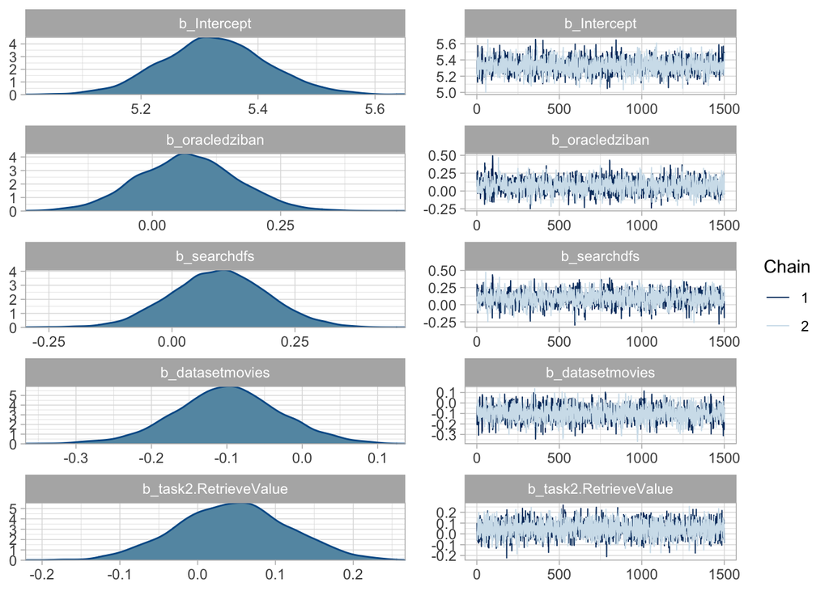

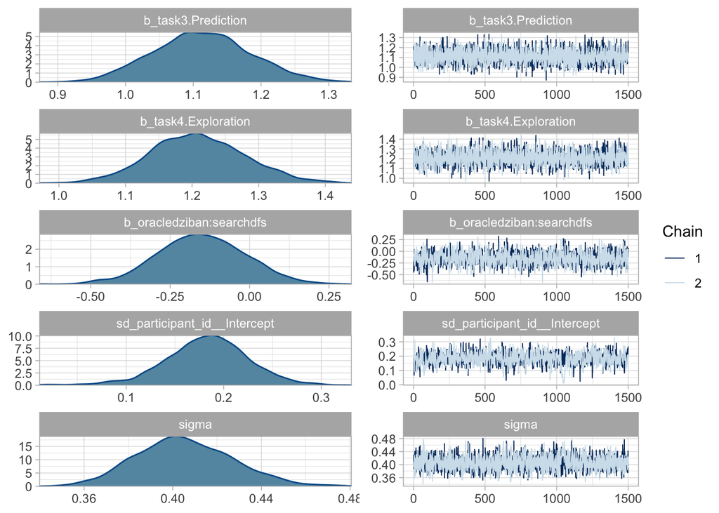

```r
plot(model)
```

In our pairs plots, we want to make sure we don’t have highly correlated parameters (highly correlated parameters means that our model has difficulty differentiating the effect of such parameters).

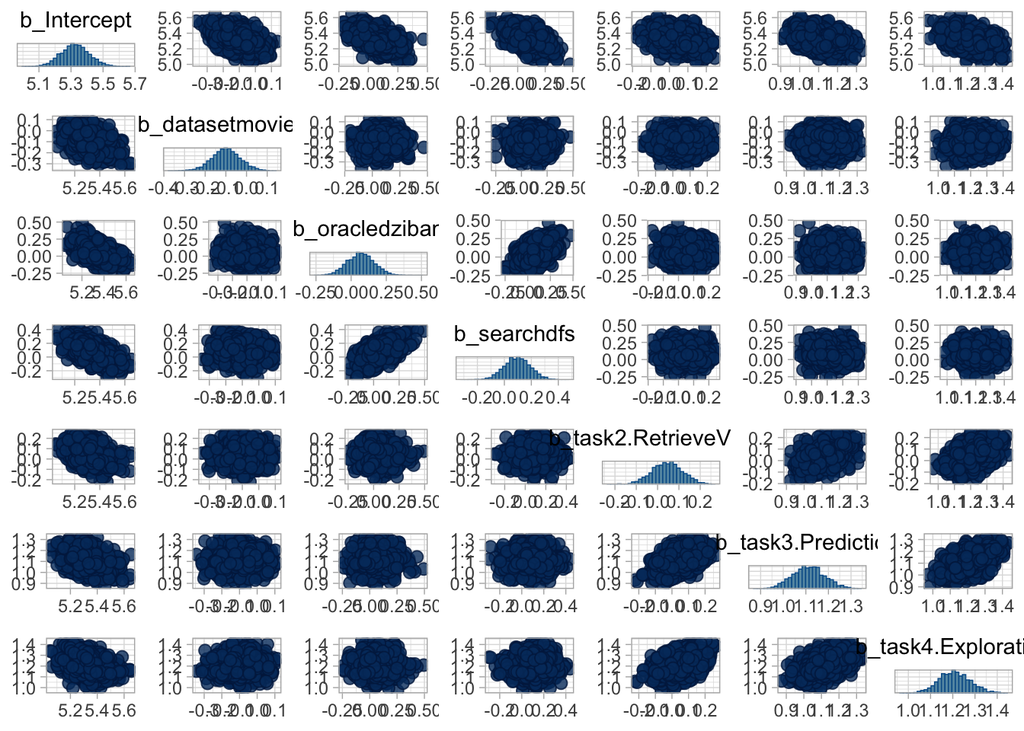

```r
pairs(
  model,
  pars = c("b_Intercept",
          "b_datasetmovies",
           "b_oracledziban",
           "b_searchdfs",
           "b_task2.RetrieveValue",
            "b_task3.Prediction",
            "b_task4.Exploration"),
  fixed = TRUE
)
```

```r
draw_data <- time_data %>%
  add_fitted_draws(model, seed = seed, re_formula = NA)

for (task_name in task_list) {
  draw_data_sub <- subset(draw_data, task == task_name)

  plot <- posterior_draws_plot(draw_data_sub, "dataset", FALSE, "Predicted Mean Completion Time (seconds)", "Oracle/Search Combination")
  plot
  filename = gsub("^.*\\.","", task_name )
  filename = gsub(" ", "_", filename)
  filename = paste("time", filename, sep = "")

  ggsave(
    file = paste(filename, ".png", sep = ""),
    plot = plot,
    path = "../plots/posterior_draws/time", width = 7, height = 7
  )

  fit_info <- draw_data_sub %>% group_by(search, oracle, dataset) %>% mean_qi(.value, .width = c(.95, .5))
  fit_info
  write.csv(fit_info,
            paste("../plot_data/posterior_draws/time/", filename, ".csv", sep = ""),
            row.names = FALSE)
}
```

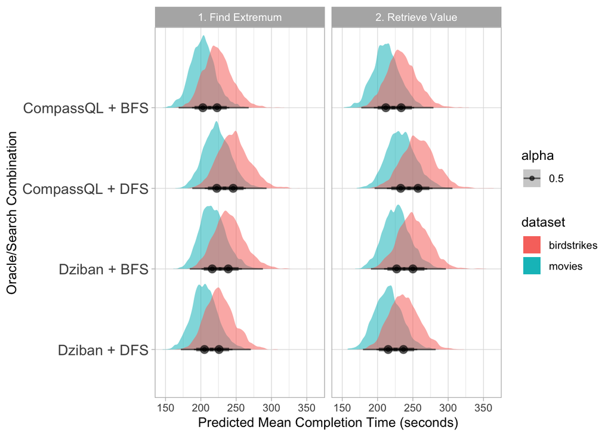

[output not shown]

```r
plot_data <- draw_data
plot_data <- plot_data[plot_data$task %in% c("1. Find Extremum", "2. Retrieve Value"),]
plot_data$task <- factor(plot_data$task)
plot_data$oracle<- gsub('compassql', 'CompassQL', plot_data$oracle)
plot_data$oracle<- gsub('dziban', 'Dziban', plot_data$oracle)
plot_data$search<- gsub('bfs', 'BFS', plot_data$search)
plot_data$search<- gsub('dfs', 'DFS', plot_data$search)

plot_data$condition <- paste(plot_data$oracle, plot_data$search, sep=" + ")
draw_plot <- posterior_draws_plot(plot_data, "dataset", TRUE, "Predicted Mean Completion Time (seconds)", "Oracle/Search Combination") + theme(axis.text.y=element_text(size=12))

draw_plot
```

## Differences Between Conditions

Next, we want to see if there is any significant difference in completion time between the two search algorithms (bfs and dfs) and the two oracles (dzbian and compassql).

```r
predictive_data <- time_data %>%
  add_fitted_draws(model, seed = seed, re_formula = NA)
```

### Differences Between Search

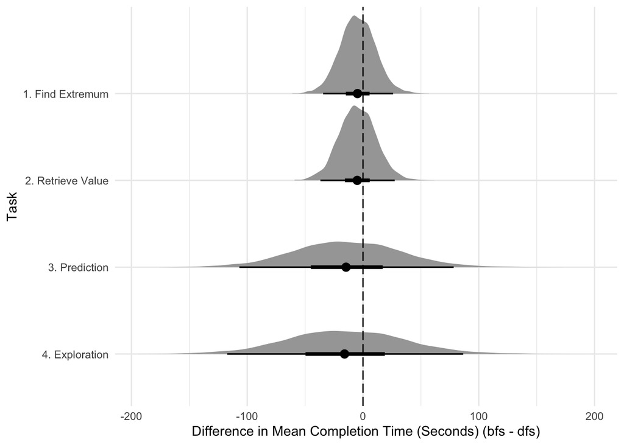

```r
search_differences <- expected_diff_in_mean_plot(predictive_data, "search", "Difference in Mean Completion Time (Seconds)",  "Task", NULL)
ggsave(file="search_time_differences.png", plot=search_differences$plot, path = "../plots/comparisons/time", width = 7, height = 7)

search_differences$plot
```

We can double-check the boundaries of the credible intervals to be sure whether or not the interval contains zero.

```r
write.csv(search_differences$intervals, "../plot_data/comparisons/time/search_time_differences.csv", sep="", row.names = FALSE)
search_differences$intervals
```

```
## # A tibble: 8 x 8
## # Groups:   search [1]
##   search    task                diff .lower .upper .width .point .interval
##   <chr>     <fct>              <dbl>  <dbl>  <dbl>  <dbl> <chr>  <chr>
## 1 bfs - dfs 1. Find Extremum   -4.54  -34.4  26.0    0.95 mean   qi
## 2 bfs - dfs 2. Retrieve Value  -4.76  -36.7  27.4    0.95 mean   qi
## 3 bfs - dfs 3. Prediction     -13.8  -107.   78.3    0.95 mean   qi
## 4 bfs - dfs 4. Exploration    -15.2  -117.   86.5    0.95 mean   qi
## 5 bfs - dfs 1. Find Extremum   -4.54  -14.8   5.67   0.5  mean   qi
## 6 bfs - dfs 2. Retrieve Value  -4.76  -15.6   5.85   0.5  mean   qi
## 7 bfs - dfs 3. Prediction     -13.8   -45.0  17.0    0.5  mean   qi
## 8 bfs - dfs 4. Exploration    -15.2   -49.6  18.9    0.5  mean   qi
```

Let’s do the above, but split it by datasets

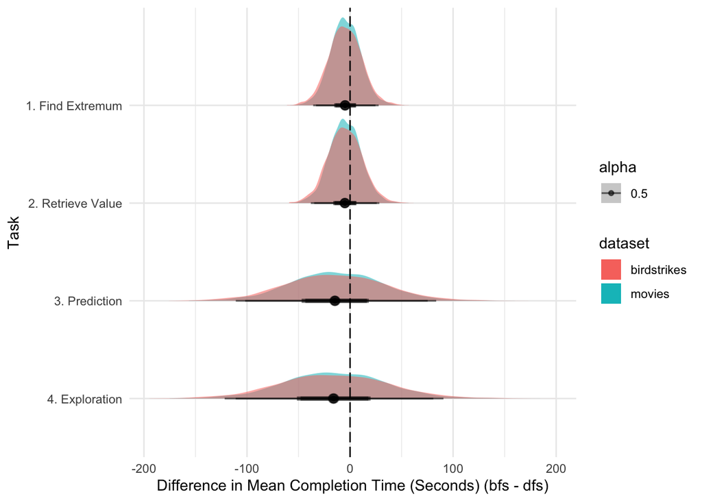

```r
search_differences_split_by_dataset <- expected_diff_in_mean_plot(predictive_data, "search", "Difference in Mean Completion Time (Seconds)",  "Task", "dataset")
ggsave(file="split_by_dataset_search_time_differences.png", plot=search_differences_split_by_dataset$plot, path = "../plots/comparisons/time", width = 7, height = 7)

search_differences_split_by_dataset$plot
```

Check intervals

```r
write.csv(search_differences_split_by_dataset$intervals, "../plot_data/comparisons/time/search_time_differences_split_by_dataset.csv", row.names = FALSE)

search_differences_split_by_dataset$intervals
```

```
## # A tibble: 16 x 9
## # Groups:   search, dataset [2]
##    search   dataset    task           diff .lower .upper .width .point .interval
##    <chr>    <fct>      <fct>         <dbl>  <dbl>  <dbl>  <dbl> <chr>  <chr>
##  1 bfs - d… birdstrik… 1. Find Ext…  -4.71  -35.8  27.7    0.95 mean   qi
##  2 bfs - d… birdstrik… 2. Retrieve…  -4.94  -38.1  28.4    0.95 mean   qi
##  3 bfs - d… birdstrik… 3. Predicti… -14.4  -111.   83.6    0.95 mean   qi
##  4 bfs - d… birdstrik… 4. Explorat… -15.7  -122.   90.6    0.95 mean   qi
##  5 bfs - d… movies     1. Find Ext…  -4.38  -33.0  24.6    0.95 mean   qi
##  6 bfs - d… movies     2. Retrieve…  -4.59  -34.8  25.9    0.95 mean   qi
##  7 bfs - d… movies     3. Predicti… -13.3  -102.   75.3    0.95 mean   qi
##  8 bfs - d… movies     4. Explorat… -14.6  -111.   80.8    0.95 mean   qi
##  9 bfs - d… birdstrik… 1. Find Ext…  -4.71  -15.4   5.94   0.5  mean   qi
## 10 bfs - d… birdstrik… 2. Retrieve…  -4.94  -16.3   6.30   0.5  mean   qi
## 11 bfs - d… birdstrik… 3. Predicti… -14.4   -47.0  18.2    0.5  mean   qi
## 12 bfs - d… birdstrik… 4. Explorat… -15.7   -51.6  19.9    0.5  mean   qi
## 13 bfs - d… movies     1. Find Ext…  -4.38  -14.1   5.34   0.5  mean   qi
## 14 bfs - d… movies     2. Retrieve…  -4.59  -15.0   5.61   0.5  mean   qi
## 15 bfs - d… movies     3. Predicti… -13.3   -43.4  16.4    0.5  mean   qi
## 16 bfs - d… movies     4. Explorat… -14.6   -48.0  17.8    0.5  mean   qi
```

### Differences Between oracle

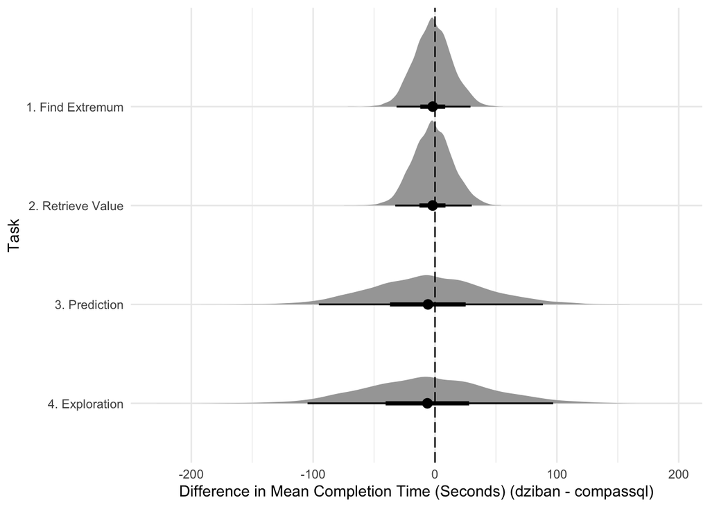

```r
oracle_differences <- expected_diff_in_mean_plot(predictive_data, "oracle", "Difference in Mean Completion Time (Seconds)",  "Task", NULL)
ggsave(file="oracle_time_differences.png", plot=oracle_differences$plot, path = "../plots/comparisons/time", width = 7, height = 7)

oracle_differences$plot
```

We can double-check the boundaries of the credible intervals to be sure whether or not the interval contains zero.

```r
write.csv(oracle_differences$intervals, "../plot_data/comparisons/time/oracle_time_differences.csv", sep="", row.names = FALSE)
oracle_differences$intervals
```

```
## # A tibble: 8 x 8
## # Groups:   oracle [1]
##   oracle            task              diff .lower .upper .width .point .interval
##   <chr>             <fct>            <dbl>  <dbl>  <dbl>  <dbl> <chr>  <chr>
## 1 dziban - compass… 1. Find Extremum -1.76  -31.5  29.1    0.95 mean   qi
## 2 dziban - compass… 2. Retrieve Val… -1.88  -32.6  30.2    0.95 mean   qi
## 3 dziban - compass… 3. Prediction    -5.32  -95.3  88.5    0.95 mean   qi
## 4 dziban - compass… 4. Exploration   -5.92 -105.   97.0    0.95 mean   qi
## 5 dziban - compass… 1. Find Extremum -1.76  -12.1   8.30   0.5  mean   qi
## 6 dziban - compass… 2. Retrieve Val… -1.88  -12.8   8.60   0.5  mean   qi
## 7 dziban - compass… 3. Prediction    -5.32  -37.0  25.2    0.5  mean   qi
## 8 dziban - compass… 4. Exploration   -5.92  -40.5  28.0    0.5  mean   qi
```

Let’s do the above, but split it by datasets

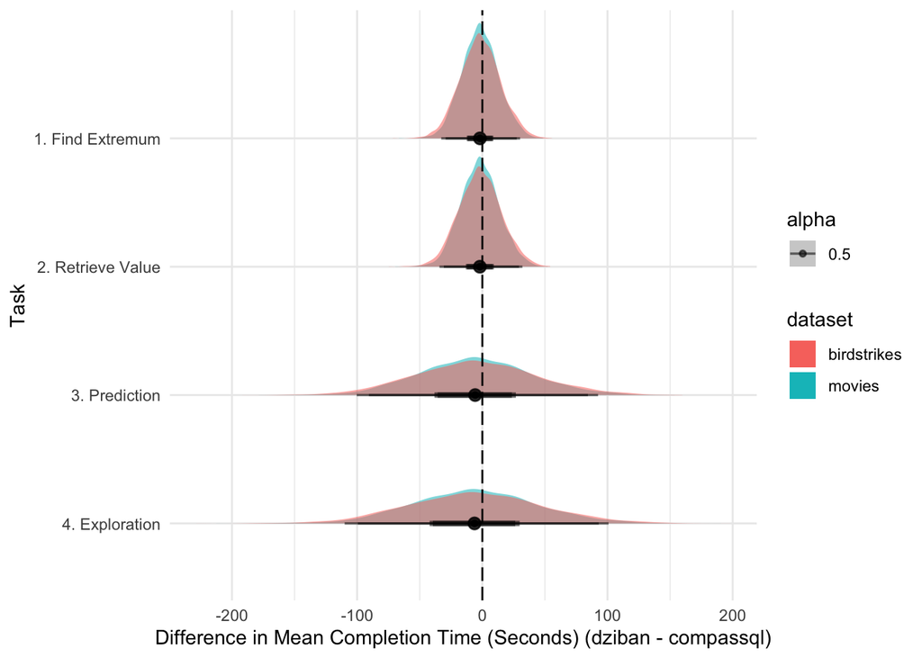

```r
oracle_differences_subset_split_by_dataset <- expected_diff_in_mean_plot(predictive_data, "oracle", "Difference in Mean Completion Time (Seconds)",  "Task", "dataset")
ggsave(file="split_by_dataset_oracle_time_differences.png", plot=oracle_differences_subset_split_by_dataset$plot, path = "../plots/comparisons/time", width = 7, height = 7)

oracle_differences_subset_split_by_dataset$plot
```

Check intervals

```r
write.csv(oracle_differences_subset_split_by_dataset$intervals, "../plot_data/comparisons/time/oracle_time_differences_split_by_dataset.csv", row.names = FALSE)
oracle_differences_subset_split_by_dataset$intervals
```

```
## # A tibble: 16 x 9
## # Groups:   oracle, dataset [2]
##    oracle       dataset   task        diff .lower .upper .width .point .interval
##    <chr>        <fct>     <fct>      <dbl>  <dbl>  <dbl>  <dbl> <chr>  <chr>
##  1 dziban - co… birdstri… 1. Find E… -1.73  -32.8  30.2    0.95 mean   qi
##  2 dziban - co… birdstri… 2. Retrie… -1.85  -34.2  32.0    0.95 mean   qi
##  3 dziban - co… birdstri… 3. Predic… -5.22 -100.   92.4    0.95 mean   qi
##  4 dziban - co… birdstri… 4. Explor… -5.80 -110.  101.     0.95 mean   qi
##  5 dziban - co… movies    1. Find E… -1.80  -29.3  27.5    0.95 mean   qi
##  6 dziban - co… movies    2. Retrie… -1.92  -30.7  29.3    0.95 mean   qi
##  7 dziban - co… movies    3. Predic… -5.43  -90.6  84.4    0.95 mean   qi
##  8 dziban - co… movies    4. Explor… -6.03  -99.4  93.0    0.95 mean   qi
##  9 dziban - co… birdstri… 1. Find E… -1.73  -12.4   8.82   0.5  mean   qi
## 10 dziban - co… birdstri… 2. Retrie… -1.85  -13.2   9.21   0.5  mean   qi
## 11 dziban - co… birdstri… 3. Predic… -5.22  -38.2  26.8    0.5  mean   qi
## 12 dziban - co… birdstri… 4. Explor… -5.80  -42.1  29.8    0.5  mean   qi
## 13 dziban - co… movies    1. Find E… -1.80  -11.7   7.93   0.5  mean   qi
## 14 dziban - co… movies    2. Retrie… -1.92  -12.2   8.21   0.5  mean   qi
## 15 dziban - co… movies    3. Predic… -5.43  -35.7  23.6    0.5  mean   qi
## 16 dziban - co… movies    4. Explor… -6.03  -39.5  26.3    0.5  mean   qi
```

### Differences Between Participant Groups

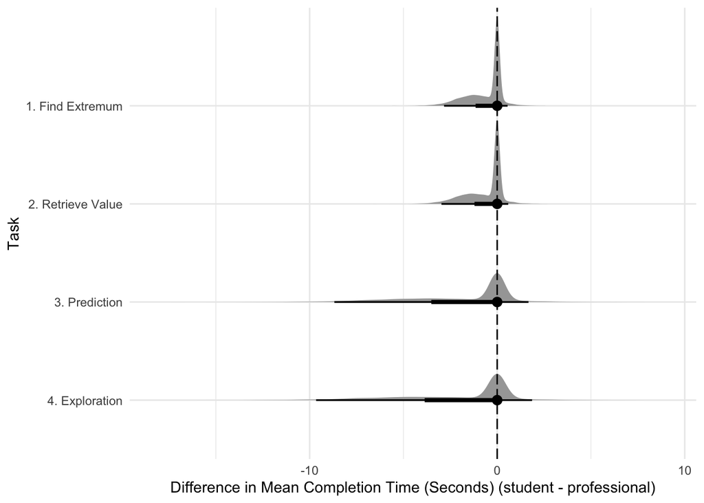

```r
participant_group_differences <- expected_diff_in_mean_plot(predictive_data, "participant_group", "Difference in Mean Completion Time (Seconds)",  "Task", NULL)
ggsave(file="participant_group_time_differences.png", plot=participant_group_differences$plot, path = "../plots/comparisons/time", width = 7, height = 7)

participant_group_differences$plot
```

We can double-check the boundaries of the credible intervals to be sure whether or not the interval contains zero.

```r
write.csv(participant_group_differences$intervals, "../plot_data/comparisons/time/participant_group_time_differences.csv", sep="", row.names = FALSE)
participant_group_differences$intervals
```

```
## # A tibble: 8 x 8
## # Groups:   participant_group [1]
##   participant_group    task           diff .lower .upper .width .point .interval
##   <chr>                <fct>         <dbl>  <dbl>  <dbl>  <dbl> <chr>  <chr>
## 1 student - professio… 1. Find Ext… -0.572  -2.83  0.556   0.95 mean   qi
## 2 student - professio… 2. Retrieve… -0.598  -2.97  0.589   0.95 mean   qi
## 3 student - professio… 3. Predicti… -1.74   -8.68  1.67    0.95 mean   qi
## 4 student - professio… 4. Explorat… -1.91   -9.65  1.86    0.95 mean   qi
## 5 student - professio… 1. Find Ext… -0.572  -1.15  0       0.5  mean   qi
## 6 student - professio… 2. Retrieve… -0.598  -1.21  0       0.5  mean   qi
## 7 student - professio… 3. Predicti… -1.74   -3.51  0       0.5  mean   qi
## 8 student - professio… 4. Explorat… -1.91   -3.87  0       0.5  mean   qi
```

## Summary Plots

Plot all of the posterior draws on one plot

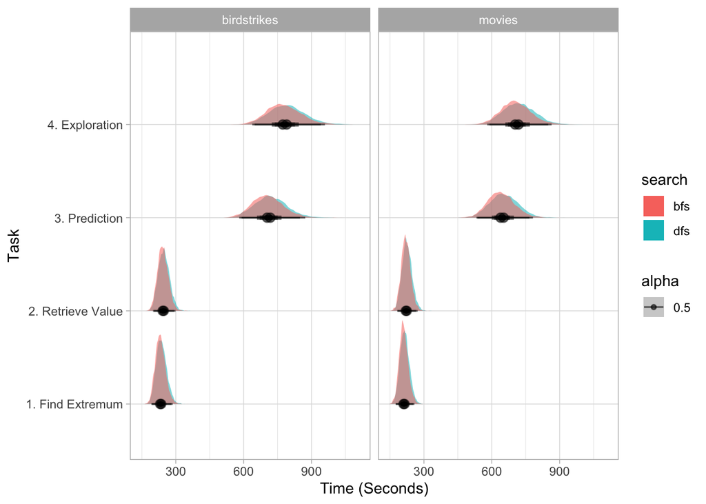

```r
plot <- draw_data %>% ggplot(aes(
    x = .value,
    y = task,
    fill = search,
    alpha = 0.5
  )) + stat_halfeye(.width = c(.95, .5)) +
    labs(x = "Time (Seconds)", y = "Task") +  facet_grid(. ~ dataset)
plot
```

#Code for additional plots (mostly subsets)

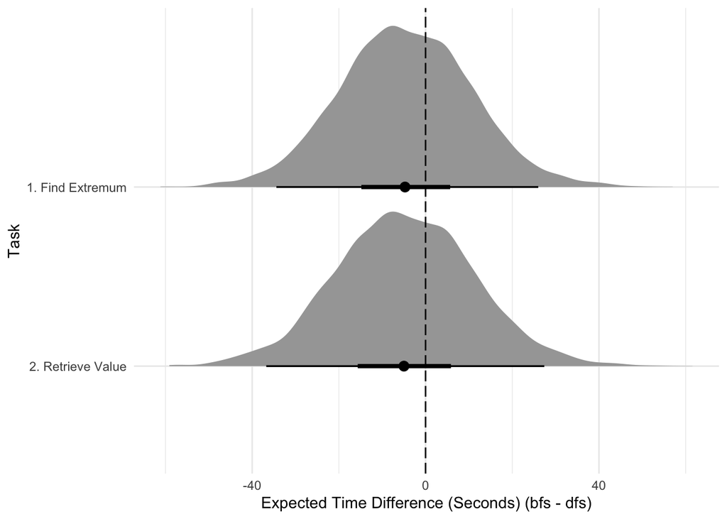

```r
predictive_data_subset <- predictive_data[predictive_data$task %in% c("1. Find Extremum", "2. Retrieve Value"),]
predictive_data_subset$task <- factor(predictive_data_subset$task)

search_differences_subset <- expected_diff_in_mean_plot(predictive_data_subset, "search", "Expected Time Difference (Seconds)",  "Task", NULL)
ggsave(file="search_time_differences_subset.png", plot=search_differences_subset$plot, path = "../plots/comparisons/time", width = 7, height = 7)

search_differences_subset$plot
```

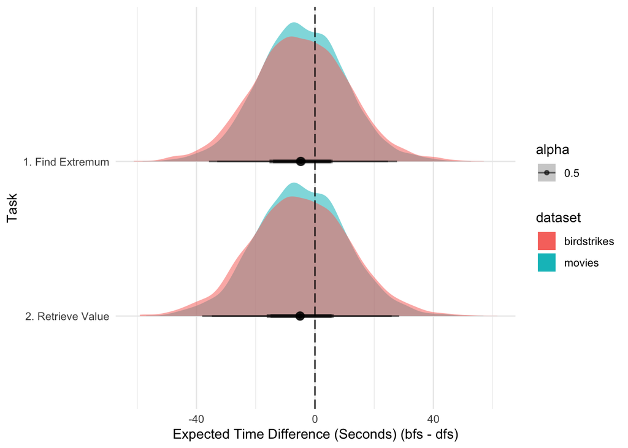

```r
diff_in_search_prediction_split_by_dataset_subset <- expected_diff_in_mean_plot(predictive_data_subset, "search", "Expected Time Difference (Seconds)",  "Task", "dataset")
ggsave(file="split_by_dataset_search_time_differences_subset.png", plot=diff_in_search_prediction_split_by_dataset_subset$plot, path = "../plots/comparisons/time", width = 7, height = 7)

diff_in_search_prediction_split_by_dataset_subset$plot
```

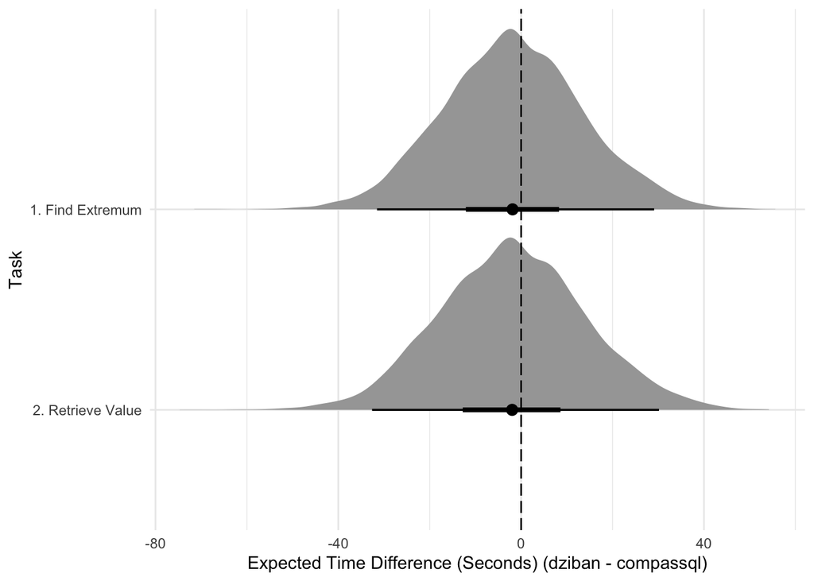

```r
oracle_differences_subset <- expected_diff_in_mean_plot(predictive_data_subset, "oracle", "Expected Time Difference (Seconds)",  "Task", NULL)
ggsave(file="oracle_time_differences_subset.png", plot=oracle_differences_subset$plot, path = "../plots/comparisons/time", width = 7, height = 7)

oracle_differences_subset$plot
```

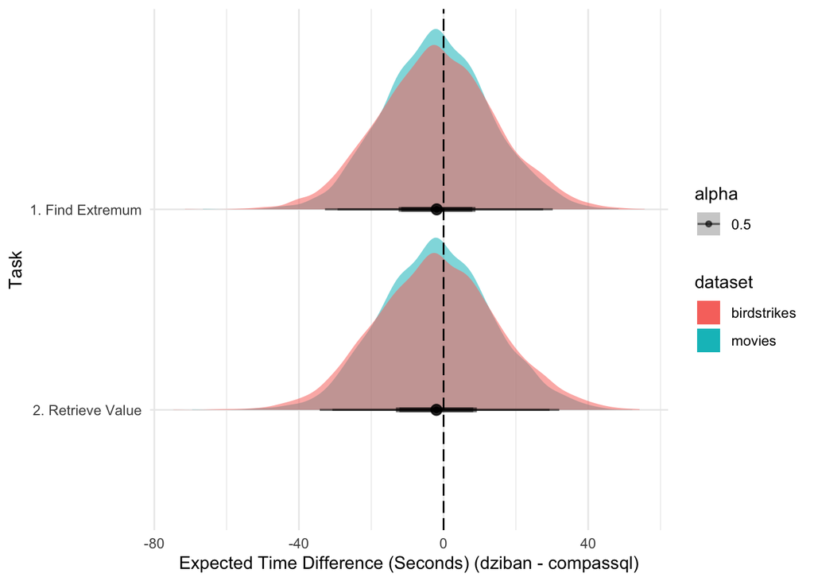

```r
oracle_differences_subset_split_by_dataset_subset <- expected_diff_in_mean_plot(predictive_data_subset, "oracle", "Expected Time Difference (Seconds)",  "Task", "dataset")
ggsave(file="split_by_dataset_oracle_time_differences_subset.png", plot=oracle_differences_subset_split_by_dataset_subset$plot, path = "../plots/comparisons/time", width = 7, height = 7)

oracle_differences_subset_split_by_dataset_subset$plot
```